# Capstone Project

Adrián Fabela

3/24/2021

## Description

This project has the aim of developing an algorythm driven by a widget in Shiny which can suggest your next word in a sentence according to what is most utilized in the social media world and the news. Social media’s fast growth in the last year has lead to thougher requirements from cellphone users when it comes to writing texts to a friend, posting their status in their profile or even while writting news. For such reason, a big amount of companies decided to get into the race to provide the fastest, most accurate text predicion algorythm to cellphone OS.

The algorythm which will be deployed here is limited to the first fours words in a sentence due to the limitation of memory capability of the hardware at use. Two approaches will be defined in order to deploy the algorythm. The first algorythm will be based in pure statistics and the second one will be based on machine learning under the forest tree method.

## Algorythms

As stated previously the algorythm will be built with two processes behind it. The statistics-based one will be used for suggesting the first word and the forest tree machine learning one will be applied starting the second word all the way until the fourt.

### Pure statistcs

The idea of this algorythm is to provide three options as the first word prior to the user typing anything on the text box. The three words will be dragged from the top three words which appear in 100k twitters in the US.

### Machine Learning

The seconds, thirds and fourth word will be predicted by a random forrest machine learning algorythm. Since the algorythm’s output is limited to that word’s position there is a need to deploy arandom foest model for each of the positions.

## Data cleaning

The utilized data source is from the *US Twitter* file provided by the coursera web page for purpose of this project which had over 2.5 million lines and were way to many to be processed. Considering the limitation of the hardware utilized to do this project only the first 100,000 twitters were taken to build the data frame which will be then split 70% for training and 30% for testing.

## Analysis

It can be seen that the top five words which popped up in the 100,000 lines of twitters are the following:

```
##        V1   V2
## 10      I 7593
## 7     I'm 1542
## 8     The 1510
## 18     RT 1425
## 38 Thanks 1239
```

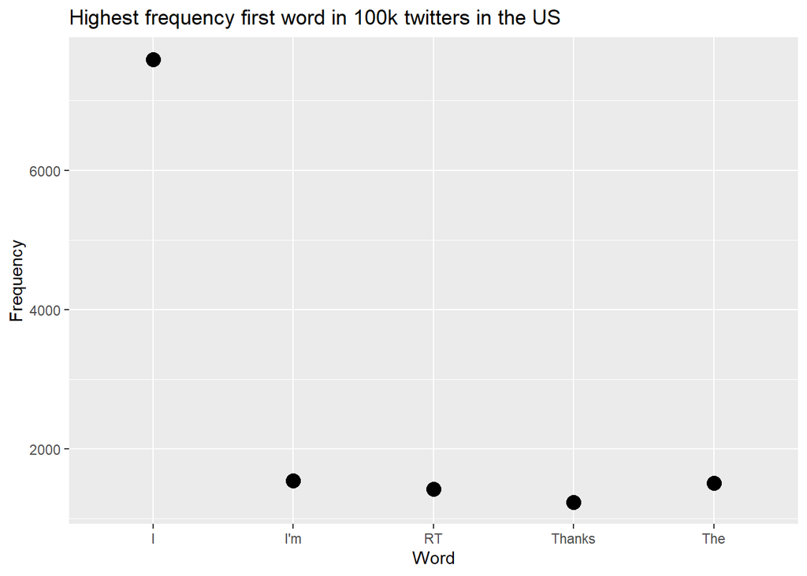